# Lab 12

Makesh Srinivasan 19BCE1717

23/11/2021

## Sports analytics

Instructions: Choose data set related to sports of your choice and do the possible analysis. provide your submission in html format. Mention the data set in the submission source: https://www.kaggle.com/idoyo92/epl-stats-20192020

For this exercise, I plan to do the following. 1) Data manipulation 2) Data cleaning 3) Visualisation and plotting 4) Regression analysis

NOTE: all the previous exercises (8 in total) are incorporated into these four topics.

#### 1) Data manipulation

The dataset used for this exercise is a very large one, there are many columns and over 500 observations. This dataset is not meant for linear regression or multi-linear regression as the purpose behind this data is to provide a summary of English Premier League tournament of a given year. This dataset is useful in analysing and visualising the data, not predicting any attribute. However, for the sake of this exercise, I have trimmed the dataset and used one attribute for prediction using linear regression. The performance of the same is not guaranteed. I will find out as I experiment with the dataset.

1.1) Import the dataset “epl2020.csv”

```r
data <- read.csv("epl2020.csv")
head(data)
```

```
##   X h_a       xG      xGA     npxG    npxGA deep deep_allowed scored missed
## 1 1   h 2.234560 0.842407 2.234560 0.842407   11            5      4      1
## 2 2   a 0.842407 2.234560 0.842407 2.234560    5           11      1      4
## 3 3   a 3.183770 1.200300 2.422640 1.200300    9            1      5      0
## 4 4   h 1.200300 3.183770 1.200300 2.422640    1            9      0      5
## 5 5   h 1.340990 1.598640 1.340990 1.598640    4            6      1      1
## 6 6   a 0.855516 0.670022 0.855516 0.670022    5            7      3      0
##     xpts result          date wins draws loses pts     npxGD      teamId
## 1 2.3863      w  8/9/19 20:00    1     0     0   3  1.392153   Liverpool
## 2 0.4405      l  8/9/19 20:00    0     0     1   0 -1.392153     Norwich
## 3 2.6312      w 8/10/19 12:30    1     0     0   3  1.222340    Man City
## 4 0.2522      l 8/10/19 12:30    0     0     1   0 -1.222340    West Ham
## 5 1.0172      d 8/10/19 15:00    0     1     0   1 -0.257650 Bournemouth
## 6 1.5458      w 8/10/19 15:00    1     0     0   3  0.185494    Brighton
##    ppda_cal allowed_ppda matchtime tot_points round tot_goal tot_con Referee.x
```

[output cut: 20 more lines]

1.2) Explore the structure of the dataset and print the dimension of the same

```r
str(data)
```

```
## 'data.frame':    576 obs. of  45 variables:
##  $ X           : int  1 2 3 4 5 6 7 8 9 10 ...
##  $ h_a         : chr  "h" "a" "a" "h" ...
##  $ xG          : num  2.235 0.842 3.184 1.2 1.341 ...
##  $ xGA         : num  0.842 2.235 1.2 3.184 1.599 ...
##  $ npxG        : num  2.235 0.842 2.423 1.2 1.341 ...
##  $ npxGA       : num  0.842 2.235 1.2 2.423 1.599 ...
##  $ deep        : int  11 5 9 1 4 5 0 5 5 6 ...
##  $ deep_allowed: int  5 11 1 9 6 7 9 5 5 4 ...
##  $ scored      : int  4 1 5 0 1 3 3 0 0 1 ...
##  $ missed      : int  1 4 0 5 1 0 0 0 0 1 ...
##  $ xpts        : num  2.386 0.441 2.631 0.252 1.017 ...
##  $ result      : chr  "w" "l" "w" "l" ...
##  $ date        : chr  "8/9/19 20:00" "8/9/19 20:00" "8/10/19 12:30" "8/10/19 12:30" ...
##  $ wins        : int  1 0 1 0 0 1 1 0 0 0 ...
```

[output cut: 31 more lines]

```r
print("Dimension: ")
```

```
## [1] "Dimension: "
```

```r
dim(data)
```

```
## [1] 576  45
```

We can see that there are several columns whose datatypes are chr, while others are int or num. For regression analysis (step-4), we need to convert the chr datatype to numeric datatype. This conversion is generally done in data cleaning stage, but can also be done in the data manipulation step.

We need to decide which columns to keep and which to omit. The h_c column shows the home and away games, matchDay shows the day, teamId shows the team name, Referee.x shows the referee, result shows the results - win or loss, and finally, the data shows the date. Let us assume that the label or the prediction variable in the dataset is xG (expected goals). Let us also assume that date, matchday and referee do not play a major role in the prediction of the goals (this is done to reduce the size of the dataset so that I can explore the relevant parts in 100 minutes of this lab. The time taken to convert the values will be extrememly tedious. Normally, this must be done based on correlation).

1.3) Convert chr to numberic types

```r
colnames(data)
```

```
##  [1] "X"            "h_a"          "xG"           "xGA"          "npxG"
##  [6] "npxGA"        "deep"         "deep_allowed" "scored"       "missed"
## [11] "xpts"         "result"       "date"         "wins"         "draws"
## [16] "loses"        "pts"          "npxGD"        "teamId"       "ppda_cal"
## [21] "allowed_ppda" "matchtime"    "tot_points"   "round"        "tot_goal"
## [26] "tot_con"      "Referee.x"    "HS.x"         "HST.x"        "HF.x"
## [31] "HC.x"         "HY.x"         "HR.x"         "AS.x"         "AST.x"
## [36] "AF.x"         "AC.x"         "AY.x"         "AR.x"         "B365H.x"
## [41] "B365D.x"      "B365A.x"      "HtrgPerc"     "AtrgPerc"     "matchDay"
```

```r
unique(data["teamId"])
```

```
##              teamId
## 1         Liverpool
## 2           Norwich
## 3          Man City
## 4          West Ham
## 5       Bournemouth
## 6          Brighton
## 7           Burnley
## 8    Crystal Palace
## 9           Everton
## 10 Sheffield United
## 11      Southampton
## 12          Watford
## 13      Aston Villa
## 14        Tottenham
## 15          Arsenal
## 16        Leicester
## 17 Newcastle United
## 18           Wolves
## 19          Chelsea
## 20          Man Utd
```

```r
unique(data["h_a"])
```

```
##   h_a
## 1   h
## 2   a
```

```r
unique(data["result"])
```

```
##   result
## 1      w
## 2      l
## 5      d
```

```r
data[data$teamId=="Liverpool", 'teamId'] <- as.numeric(0)
data[data$teamId=="Norwich", 'teamId'] <- as.numeric(1)
data[data$teamId=="Man City", 'teamId'] <- as.numeric(2)
data[data$teamId=="West Ham", 'teamId'] <- as.numeric(3)
data[data$teamId=="Bournemouth", 'teamId'] <- as.numeric(4)
data[data$teamId=="Brighton", 'teamId'] <- as.numeric(5)
data[data$teamId=="Burnley", 'teamId'] <- as.numeric(6)
data[data$teamId=="Crystal Palace", 'teamId'] <- as.numeric(7)
data[data$teamId=="Everton", 'teamId'] <- as.numeric(8)
data[data$teamId=="Sheffield United", 'teamId'] <- as.numeric(9)
data[data$teamId=="Southampton", 'teamId'] <- as.numeric(10)
data[data$teamId=="Watford", 'teamId'] <- as.numeric(11)
data[data$teamId=="Aston Villa", 'teamId'] <- as.numeric(12)
data[data$teamId=="Tottenham", 'teamId'] <- as.numeric(13)
data[data$teamId=="Arsenal", 'teamId'] <- as.numeric(14)
data[data$teamId=="Leicester", 'teamId'] <- as.numeric(15)
data[data$teamId=="Newcastle United", 'teamId'] <- as.numeric(16)
data[data$teamId=="Wolves", 'teamId'] <- as.numeric(17)
data[data$teamId=="Chelsea", 'teamId'] <- as.numeric(18)
data[data$teamId=="Man Utd", 'teamId'] <- as.numeric(19)

data[data$h_a=="h", 'h_a'] <- as.numeric(1)
data[data$h_a=="a", 'h_a'] <- as.numeric(0)

data[data$result=="w", 'result'] <- as.numeric(1)
data[data$result=="d", 'result'] <- as.numeric(0)
data[data$result=="l", 'result'] <- as.numeric(-1)

data$teamId = as.numeric(as.character(data$teamId))
data$h_a = as.numeric(as.character(data$h_a))
data$result = as.numeric(as.character(data$result))

head(data, 7)
```

```
##   X h_a       xG      xGA     npxG    npxGA deep deep_allowed scored missed
## 1 1   1 2.234560 0.842407 2.234560 0.842407   11            5      4      1
## 2 2   0 0.842407 2.234560 0.842407 2.234560    5           11      1      4
## 3 3   0 3.183770 1.200300 2.422640 1.200300    9            1      5      0
## 4 4   1 1.200300 3.183770 1.200300 2.422640    1            9      0      5
## 5 5   1 1.340990 1.598640 1.340990 1.598640    4            6      1      1
## 6 6   0 0.855516 0.670022 0.855516 0.670022    5            7      3      0
## 7 7   1 0.909241 1.087520 0.909241 1.087520    0            9      3      0
##     xpts result          date wins draws loses pts     npxGD teamId  ppda_cal
## 1 2.3863      1  8/9/19 20:00    1     0     0   3  1.392153      0  5.942857
## 2 0.4405     -1  8/9/19 20:00    0     0     1   0 -1.392153      1 21.454545
## 3 2.6312      1 8/10/19 12:30    1     0     0   3  1.222340      2  6.935484
## 4 0.2522     -1 8/10/19 12:30    0     0     1   0 -1.222340      3 16.400000
## 5 1.0172      0 8/10/19 15:00    0     1     0   1 -0.257650      4 13.600000
## 6 1.5458      1 8/10/19 15:00    1     0     0   3  0.185494      5 11.500000
```

[output cut: 25 more lines]

```r
str(data)
```

```
## 'data.frame':    576 obs. of  45 variables:
##  $ X           : int  1 2 3 4 5 6 7 8 9 10 ...
##  $ h_a         : num  1 0 0 1 1 0 1 1 0 0 ...
##  $ xG          : num  2.235 0.842 3.184 1.2 1.341 ...
##  $ xGA         : num  0.842 2.235 1.2 3.184 1.599 ...
##  $ npxG        : num  2.235 0.842 2.423 1.2 1.341 ...
##  $ npxGA       : num  0.842 2.235 1.2 2.423 1.599 ...
##  $ deep        : int  11 5 9 1 4 5 0 5 5 6 ...
##  $ deep_allowed: int  5 11 1 9 6 7 9 5 5 4 ...
##  $ scored      : int  4 1 5 0 1 3 3 0 0 1 ...
##  $ missed      : int  1 4 0 5 1 0 0 0 0 1 ...
##  $ xpts        : num  2.386 0.441 2.631 0.252 1.017 ...
##  $ result      : num  1 -1 1 -1 0 1 1 0 0 0 ...
##  $ date        : chr  "8/9/19 20:00" "8/9/19 20:00" "8/10/19 12:30" "8/10/19 12:30" ...
##  $ wins        : int  1 0 1 0 0 1 1 0 0 0 ...
```

[output cut: 31 more lines]

We can now remove the rest of the chr dataype attributes as they will be of very little use.

```r
# Remove the 2 columns:
data <- subset(data, select = -c(matchDay, Referee.x, date))
str(data)
```

```
## 'data.frame':    576 obs. of  42 variables:
##  $ X           : int  1 2 3 4 5 6 7 8 9 10 ...
##  $ h_a         : num  1 0 0 1 1 0 1 1 0 0 ...
##  $ xG          : num  2.235 0.842 3.184 1.2 1.341 ...
##  $ xGA         : num  0.842 2.235 1.2 3.184 1.599 ...
##  $ npxG        : num  2.235 0.842 2.423 1.2 1.341 ...
##  $ npxGA       : num  0.842 2.235 1.2 2.423 1.599 ...
##  $ deep        : int  11 5 9 1 4 5 0 5 5 6 ...
##  $ deep_allowed: int  5 11 1 9 6 7 9 5 5 4 ...
##  $ scored      : int  4 1 5 0 1 3 3 0 0 1 ...
##  $ missed      : int  1 4 0 5 1 0 0 0 0 1 ...
##  $ xpts        : num  2.386 0.441 2.631 0.252 1.017 ...
##  $ result      : num  1 -1 1 -1 0 1 1 0 0 0 ...
##  $ wins        : int  1 0 1 0 0 1 1 0 0 0 ...
##  $ draws       : int  0 0 0 0 1 0 0 1 1 1 ...
```

[output cut: 28 more lines]

Now, all the datatypes are numeric or int. We can proceed to the next step

#### 2) Data cleaning

```r
library(tidyverse)
```

2.1) Check for NA values in the dataset

```r
print(paste("Number of missing values = ", sum(is.na(data))))
```

```
## [1] "Number of missing values =  0"
```

2.2) Check for duplicate entries:

```r
print(paste("Number of duplicate entries = ", sum(duplicated(data))))
```

```
## [1] "Number of duplicate entries =  0"
```

```r
summary(data)
```

```
##        X              h_a            xG               xGA
##  Min.   :  1.0   Min.   :0.0   Min.   :0.05413   Min.   :0.05413
##  1st Qu.:144.8   1st Qu.:0.0   1st Qu.:0.84003   1st Qu.:0.84003
##  Median :288.5   Median :0.5   Median :1.27536   Median :1.27536
##  Mean   :288.5   Mean   :0.5   Mean   :1.46009   Mean   :1.46009
##  3rd Qu.:432.2   3rd Qu.:1.0   3rd Qu.:1.97355   3rd Qu.:1.97355
##  Max.   :576.0   Max.   :1.0   Max.   :6.63049   Max.   :6.63049
##       npxG             npxGA              deep         deep_allowed
##  Min.   :0.05413   Min.   :0.05413   Min.   : 0.000   Min.   : 0.000
##  1st Qu.:0.78406   1st Qu.:0.78406   1st Qu.: 4.000   1st Qu.: 4.000
##  Median :1.23067   Median :1.23067   Median : 6.000   Median : 6.000
##  Mean   :1.37181   Mean   :1.37181   Mean   : 6.623   Mean   : 6.623
##  3rd Qu.:1.86949   3rd Qu.:1.86949   3rd Qu.: 9.000   3rd Qu.: 9.000
##  Max.   :5.86932   Max.   :5.86932   Max.   :31.000   Max.   :31.000
##      scored          missed           xpts            result        wins
##  Min.   :0.000   Min.   :0.000   Min.   :0.0004   Min.   :-1   Min.   :0.000
##  1st Qu.:0.000   1st Qu.:0.000   1st Qu.:0.6368   1st Qu.:-1   1st Qu.:0.000
##  Median :1.000   Median :1.000   Median :1.3214   Median : 0   Median :0.000
##  Mean   :1.361   Mean   :1.361   Mean   :1.3920   Mean   : 0   Mean   :0.375
##  3rd Qu.:2.000   3rd Qu.:2.000   3rd Qu.:2.1387   3rd Qu.: 1   3rd Qu.:1.000
##  Max.   :9.000   Max.   :9.000   Max.   :2.9992   Max.   : 1   Max.   :1.000
##      draws          loses            pts            npxGD
##  Min.   :0.00   Min.   :0.000   Min.   :0.000   Min.   :-5.5246
##  1st Qu.:0.00   1st Qu.:0.000   1st Qu.:0.000   1st Qu.:-0.8727
##  Median :0.00   Median :0.000   Median :1.000   Median : 0.0000
##  Mean   :0.25   Mean   :0.375   Mean   :1.375   Mean   : 0.0000
##  3rd Qu.:0.25   3rd Qu.:1.000   3rd Qu.:3.000   3rd Qu.: 0.8727
##  Max.   :1.00   Max.   :1.000   Max.   :3.000   Max.   : 5.5246
##      teamId          ppda_cal       allowed_ppda      matchtime
##  Min.   : 0.000   Min.   : 3.189   Min.   : 3.189   Min.   :11.00
##  1st Qu.: 4.750   1st Qu.: 7.715   1st Qu.: 7.715   1st Qu.:14.00
##  Median : 9.500   Median :10.184   Median :10.184   Median :15.00
##  Mean   : 9.502   Mean   :12.302   Mean   :12.302   Mean   :15.52
##  3rd Qu.:15.000   3rd Qu.:14.439   3rd Qu.:14.439   3rd Qu.:17.00
##  Max.   :19.000   Max.   :60.000   Max.   :60.000   Max.   :20.00
##    tot_points        round         tot_goal        tot_con           HS.x
##  Min.   : 0.00   Min.   : 1.0   Min.   : 0.00   Min.   : 0.00   Min.   : 3.00
##  1st Qu.: 9.00   1st Qu.: 8.0   1st Qu.: 9.00   1st Qu.:10.00   1st Qu.:10.00
##  Median :18.00   Median :15.0   Median :20.00   Median :20.00   Median :13.00
##  Mean   :20.44   Mean   :14.9   Mean   :20.89   Mean   :20.92   Mean   :13.78
```

[output cut: 15 more lines]

```
##  Max.   :1.00000   Max.   :25.00   Max.   :15.000   Max.   :24.0
##       AC.x             AY.x            AR.x           B365H.x
##  Min.   : 0.000   Min.   :0.000   Min.   :0.0000   Min.   : 1.070
##  1st Qu.: 3.000   1st Qu.:1.000   1st Qu.:0.0000   1st Qu.: 1.607
##  Median : 5.000   Median :2.000   Median :0.0000   Median : 2.200
##  Mean   : 4.917   Mean   :1.875   Mean   :0.0625   Mean   : 2.867
##  3rd Qu.: 7.000   3rd Qu.:3.000   3rd Qu.:0.0000   3rd Qu.: 3.100
##  Max.   :16.000   Max.   :6.000   Max.   :1.0000   Max.   :15.000
##     B365D.x         B365A.x          HtrgPerc         AtrgPerc
##  Min.   : 3.10   Min.   : 1.140   Min.   :0.0000   Min.   :0.0000
##  1st Qu.: 3.40   1st Qu.: 2.300   1st Qu.:0.2475   1st Qu.:0.2500
##  Median : 3.75   Median : 3.350   Median :0.3333   Median :0.3333
##  Mean   : 4.32   Mean   : 4.774   Mean   :0.3484   Mean   :0.3613
##  3rd Qu.: 4.75   3rd Qu.: 5.750   3rd Qu.:0.4444   3rd Qu.:0.4545
##  Max.   :13.00   Max.   :26.000   Max.   :1.0000   Max.   :1.0000
```

There are no missing values or duplicate entries. Hence, no further cleaning is needed for this dataset.

#### 3) Data visualisation and plotting

Import the necessary libraries

```r
library(dplyr)
library(caret)
```

```r
library(ggplot2)
library(lattice)
library(e1071)
```

3.1) How many games did Arsenal win, lose, and draw while playing its home game?

```r
# Arsenal team ID is 14
arsenal_l <- data%>%
  filter(teamId == 14 & h_a == 1 & result == -1)
arsenal_d <- data%>%
  filter(teamId == 14 & h_a == 1 & result == 0)
arsenal_w <- data%>%
  filter(teamId == 14 & h_a == 1 & result == 1)
print(paste("Total victory: ", count(arsenal_w)))
```

```
## [1] "Total victory:  7"
```

```r
print(paste("Total draw: ", count(arsenal_d)))
```

```
## [1] "Total draw:  5"
```

```r
print(paste("Total loss: ", count(arsenal_l)))
```

```
## [1] "Total loss:  3"
```

3.2) In a football game, there are many shots taken by a team to score a goal. I want to visualise the number of wins, loses and draws of Arsenal’s away game

```r
shots <- data %>%
  filter(teamId == 14 & h_a == 0) %>%
  select(result)
shots
```

```
##    result
## 1       1
## 2      -1
## 3       0
## 4       0
## 5      -1
## 6      -1
## 7       0
## 8       1
## 9       0
## 10      0
## 11      0
## 12      0
## 13      0
```

[figure not shown]

```r
pie(table(shots$result), main = 'Female Left Handers and Male Left Handers', col=rainbow(3))
```

```r
# 0 -> draw, 1 -> win and -1 -> loss of the game
```

3.3) Determine who won the tournament that season

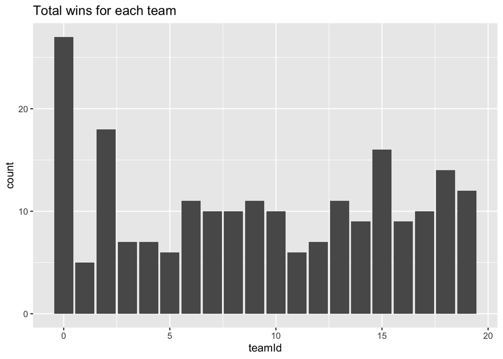

```r
# Find the total number of wins and see which team has the highest value
df1 <- data %>%
  filter(result == 1)
ggplot(df1,aes(x=teamId))+geom_bar()+ggtitle("Total wins for each team")
```

```r
# teamId = 0 corresponds to Liverpool
```

INFERENCE: Liverpool has the highest number of victories that season - verified from the news on google as well

3.4) Find out which team finished last on the table

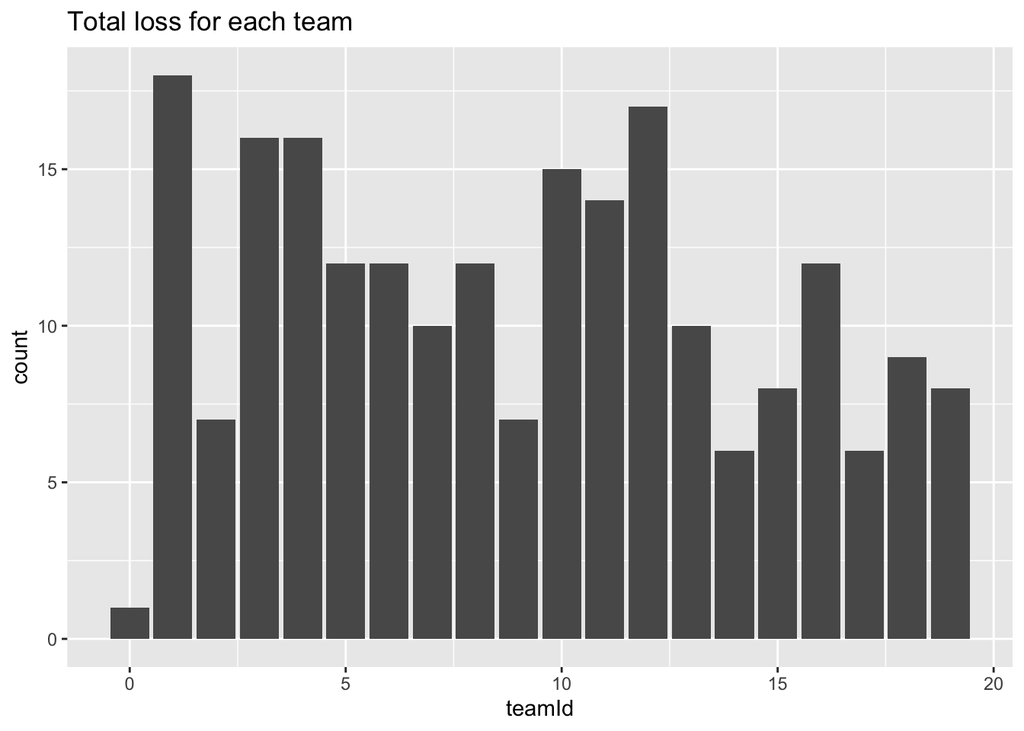

```r
df2 <- data %>%
  filter(result == -1)
ggplot(df2,aes(x=teamId))+geom_bar()+ggtitle("Total loss for each team")
```

```r
# teamId = 1 corresponds to Norwich
```

INFERENCE: The team ID 1 finished las due to highest number of losses that season

3.5) Show the ppda_cal as a distribution and show the skewness and kurtosis

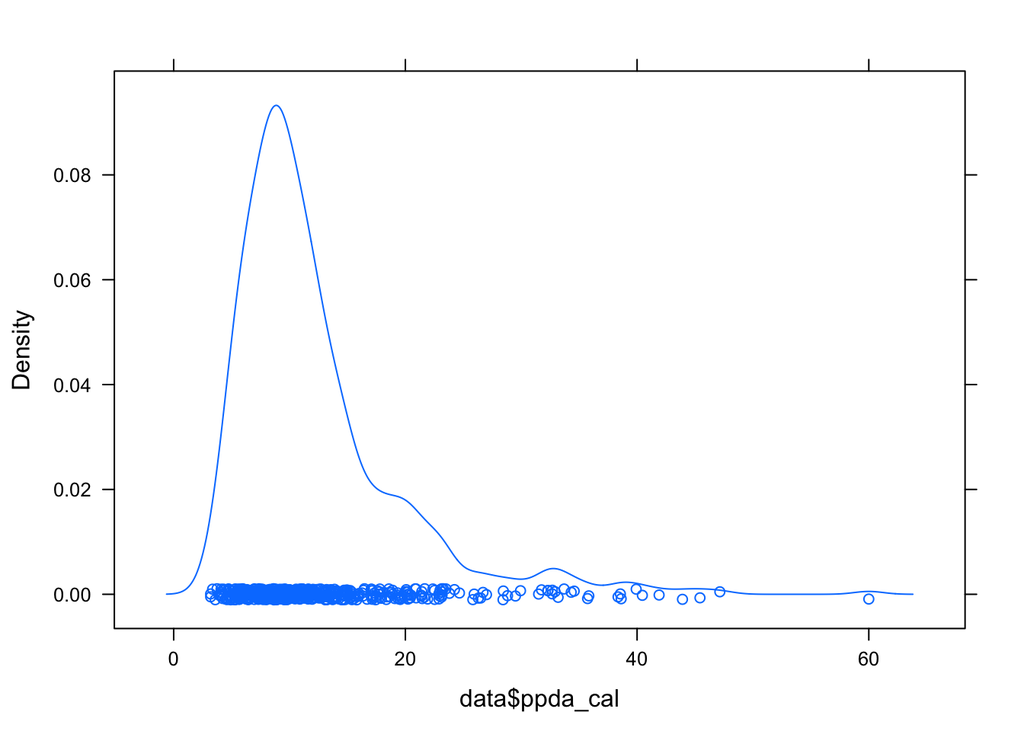

```r
densityplot(data$ppda_cal)
```

Inference: The spread is positively skewed (Leptokurtic). PPDA is a measure of pressing play VERIFICATION:

```r
print(paste("Skewness = ", skewness(data$ppda_cal)))
```

```
## [1] "Skewness =  2.17768828491333"
```

```r
print(paste("Kurtosis = ", kurtosis(data$ppda_cal)))
```

```
## [1] "Kurtosis =  6.51688963967808"
```

```r
# This means mean is greater than median greater than mode
# Leptokurtic becasue of the positive value
```

3.6) Show the same using the box plot

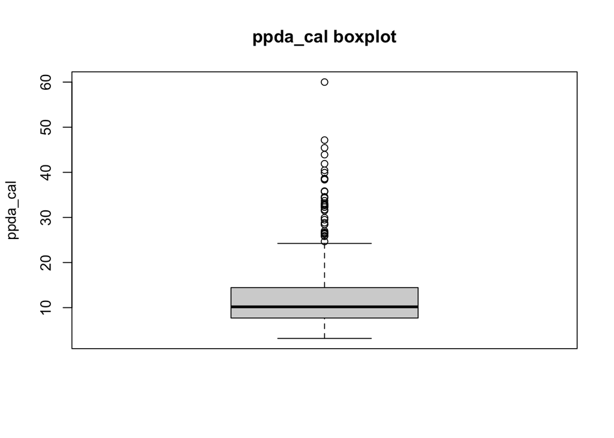

```r
boxplot(data$ppda_cal, main="ppda_cal boxplot", ylab = "ppda_cal")
```

There are many outliers as shown above.

3.7) Show the multi box plot between the xG, xGA, npxG and npxGA:

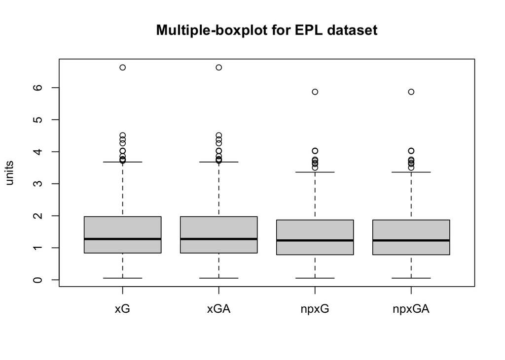

```r
boxplot(data[, 3:6], main="Multiple-boxplot for EPL dataset", ylab = "units")
```

3.8) Correlation between the features and xG expected goal attribute.

```r
cols = colnames(data)
for (c in cols) {
  print(paste("Column", c, ": ", cor(data[[c]],data$xG)))
}
```

```
## [1] "Column X :  0.0243946040327745"
## [1] "Column h_a :  0.141236145623764"
## [1] "Column xG :  1"
## [1] "Column xGA :  -0.368302479901876"
## [1] "Column npxG :  0.959138104878335"
## [1] "Column npxGA :  -0.361463737895715"
## [1] "Column deep :  0.502452776754774"
## [1] "Column deep_allowed :  -0.275256815047843"
## [1] "Column scored :  0.62746899528627"
## [1] "Column missed :  -0.249552866788346"
## [1] "Column xpts :  0.816444088249759"
## [1] "Column result :  0.478153822926007"
## [1] "Column wins :  0.473987611343066"
## [1] "Column draws :  -0.103560873603833"
## [1] "Column loses :  -0.381359950068092"
```

[output cut: 27 more lines]

3.9) Covariance between the features and expected goal attribute.

```r
cols = colnames(data)
for (c in cols) {
  print(paste("Column", c, ": ", cov(data[[c]],data$xG)))
}
```

```
## [1] "Column X :  3.54693729486957"
## [1] "Column h_a :  0.0617510566086956"
## [1] "Column xG :  0.763312588442479"
## [1] "Column xGA :  -0.281129919263685"
## [1] "Column npxG :  0.671074850524259"
## [1] "Column npxGA :  -0.252903333362067"
## [1] "Column deep :  1.88508963597373"
## [1] "Column deep_allowed :  -1.0327015657654"
## [1] "Column scored :  0.662158231550725"
## [1] "Column missed :  -0.263349243057971"
## [1] "Column xpts :  0.620060753714852"
## [1] "Column result :  0.362098558434783"
## [1] "Column wins :  0.200655544630435"
## [1] "Column draws :  -0.039212530826087"
## [1] "Column loses :  -0.161443013804348"
```

[output cut: 27 more lines]

3.11) Mean, median and std. deviation of the xG attribute.

```r
mean_charge <- mean(data$xG)
median_charge <- median(data$xG)
var_charge <- var(data$xG)
sd_charge <- sd(data$xG)
print(paste("mean_xG = ", mean_charge))
```

```
## [1] "mean_xG =  1.46008814739583"
```

```r
print(paste("median_xG = ", median_charge))
```

```
## [1] "median_xG =  1.27536"
```

```r
print(paste("var_xG = ", var_charge))
```

```
## [1] "var_xG =  0.763312588442479"
```

```r
print(paste("sd_xG = ", sd_charge))
```

```
## [1] "sd_xG =  0.873677622720462"
```

[figure not shown]

```r
gf = factor(data$result,levels = c("-1","0","1"),labels = c("loss","win","draw"))
ggplot(data,aes(x=xG,fill=h_a))+geom_histogram(binwidth = 1)+labs(title = "Distribution of height",y='Frequency')+facet_wrap(gf,ncol=2)
```

3.13) trend between xG and npxG

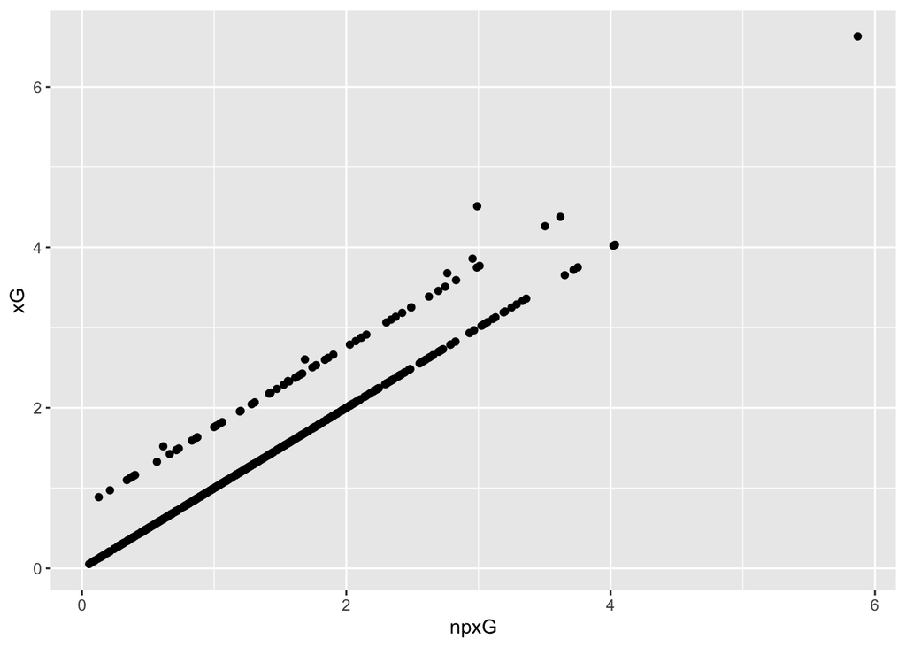

```r
ggplot(data, aes(x=npxG,y=xG))+geom_point()
```

3.14 pair plot

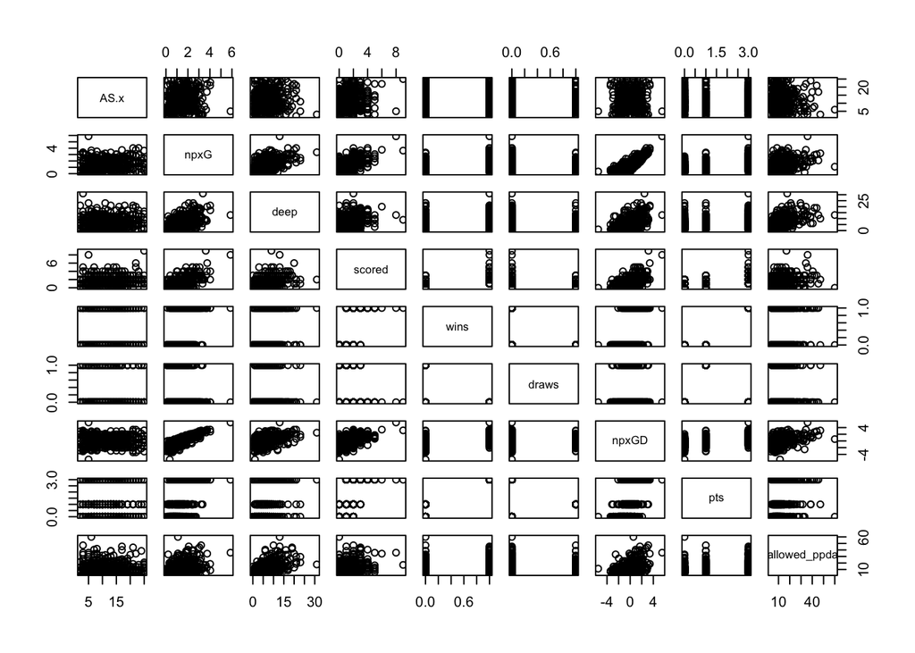

```r
pairs(data[, c("AS.x", "npxG", "deep", "scored", "wins", "draws", "npxGD", "pts", "allowed_ppda")])
```

We have seen enough plots and analysis between the variables

Step-4 can now begin.

#### 4) Rregression analysis

Build a linear regression model using all the columns, then choose the statistically significant ones and create another model. Evaluate the models using performance metrics such as R squared and RMSE values.

```r
model1 <- lm(xG~.,data=data)
model1
```

```
##
## Call:
## lm(formula = xG ~ ., data = data)
##
## Coefficients:
##  (Intercept)             X           h_a           xGA          npxG
##   -0.7011586     0.0013468    -0.0203769     0.1328717     0.6819278
##        npxGA          deep  deep_allowed        scored        missed
##    0.1054900     0.0034735     0.0014357     0.0689106    -0.0403325
##         xpts        result          wins         draws         loses
##    0.4652637    -0.0732134     0.0034014            NA            NA
##          pts         npxGD        teamId      ppda_cal  allowed_ppda
##           NA            NA    -0.0015763     0.0013191    -0.0009028
##    matchtime    tot_points         round      tot_goal       tot_con
##    0.0063185    -0.0041107    -0.0221453     0.0038651    -0.0029842
##         HS.x         HST.x          HF.x          HC.x          HY.x
##    0.0065074    -0.0013676     0.0014215    -0.0070191     0.0122751
##         HR.x          AS.x         AST.x          AF.x          AC.x
##    0.0312464    -0.0044983     0.0204797     0.0008915    -0.0008243
##         AY.x          AR.x       B365H.x       B365D.x       B365A.x
##    0.0010213    -0.0046422    -0.0088166     0.0064538    -0.0070610
##     HtrgPerc      AtrgPerc
##    0.0633177    -0.0337595
```

Summary of the model 1

```r
summary(model1)
```

```
##
## Call:
## lm(formula = xG ~ ., data = data)
##
## Residuals:
##      Min       1Q   Median       3Q      Max
## -0.67999 -0.11259 -0.02566  0.05945  1.17671
##
## Coefficients: (4 not defined because of singularities)
##                Estimate Std. Error t value Pr(>|t|)
## (Intercept)  -0.7011586  0.1260560  -5.562 4.20e-08 ***
## X             0.0013468  0.0013909   0.968  0.33335
## h_a          -0.0203769  0.0172468  -1.181  0.23793
## xGA           0.1328717  0.0411352   3.230  0.00131 **
## npxG          0.6819278  0.0258725  26.357  < 2e-16 ***
## npxGA         0.1054900  0.0388645   2.714  0.00685 **
## deep          0.0034735  0.0027423   1.267  0.20584
## deep_allowed  0.0014357  0.0026974   0.532  0.59478
## scored        0.0689106  0.0121466   5.673 2.29e-08 ***
## missed       -0.0403325  0.0123183  -3.274  0.00113 **
## xpts          0.4652637  0.0326880  14.233  < 2e-16 ***
## result       -0.0732134  0.0283035  -2.587  0.00995 **
## wins          0.0034014  0.0417505   0.081  0.93510
## draws                NA         NA      NA       NA
## loses                NA         NA      NA       NA
## pts                  NA         NA      NA       NA
## npxGD                NA         NA      NA       NA
## teamId       -0.0015763  0.0016369  -0.963  0.33598
## ppda_cal      0.0013191  0.0016577   0.796  0.42654
## allowed_ppda -0.0009028  0.0016915  -0.534  0.59376
## matchtime     0.0063185  0.0044225   1.429  0.15367
## tot_points   -0.0041107  0.0030940  -1.329  0.18455
## round        -0.0221453  0.0276620  -0.801  0.42374
## tot_goal      0.0038651  0.0023336   1.656  0.09825 .
## tot_con      -0.0029842  0.0027912  -1.069  0.28548
## HS.x          0.0065074  0.0038980   1.669  0.09561 .
## HST.x        -0.0013676  0.0101122  -0.135  0.89247
## HF.x          0.0014215  0.0028552   0.498  0.61879
## HC.x         -0.0070191  0.0033978  -2.066  0.03933 *
## HY.x          0.0122751  0.0074673   1.644  0.10079
## HR.x          0.0312464  0.0379554   0.823  0.41074
## AS.x         -0.0044983  0.0048877  -0.920  0.35782
## AST.x         0.0204797  0.0109093   1.877  0.06102 .
## AF.x          0.0008915  0.0026876   0.332  0.74024
## AC.x         -0.0008243  0.0038445  -0.214  0.83032
## AY.x          0.0010213  0.0081222   0.126  0.89998
## AR.x         -0.0046422  0.0365801  -0.127  0.89906
## B365H.x      -0.0088166  0.0114331  -0.771  0.44096
## B365D.x       0.0064538  0.0240306   0.269  0.78837
## B365A.x      -0.0070610  0.0094263  -0.749  0.45414
## HtrgPerc      0.0633177  0.1222683   0.518  0.60477
## AtrgPerc     -0.0337595  0.1072338  -0.315  0.75302
## ---
## Signif. codes:  0 '***' 0.001 '**' 0.01 '*' 0.05 '.' 0.1 ' ' 1
##
## Residual standard error: 0.2 on 538 degrees of freedom
## Multiple R-squared:  0.951,  Adjusted R-squared:  0.9476
## F-statistic: 281.9 on 37 and 538 DF,  p-value: < 2.2e-16
```

```r
sigma(model1)
```

```
## [1] 0.2000342
```

Confidence interval of the model

```r
confint(model1)
```

```
##                      2.5 %        97.5 %
## (Intercept)  -0.9487808424 -0.4535362611
## X            -0.0013855363  0.0040790890
## h_a          -0.0542562870  0.0135024039
## xGA           0.0520663802  0.2136770014
## npxG          0.6311042862  0.7327512806
## npxGA         0.0291452973  0.1818347422
## deep         -0.0019134817  0.0088605340
## deep_allowed -0.0038630171  0.0067343559
## scored        0.0450499682  0.0927711521
## missed       -0.0645302609 -0.0161346863
## xpts          0.4010519634  0.5294754292
## result       -0.1288124464 -0.0176144139
## wins         -0.0786125373  0.0854153929
## draws                   NA            NA
## loses                   NA            NA
## pts                     NA            NA
## npxGD                   NA            NA
## teamId       -0.0047918343  0.0016391708
## ppda_cal     -0.0019373241  0.0045755649
## allowed_ppda -0.0042255285  0.0024199750
## matchtime    -0.0023690241  0.0150060403
## tot_points   -0.0101885292  0.0019672178
## round        -0.0764841033  0.0321934639
## tot_goal     -0.0007190540  0.0084491657
## tot_con      -0.0084672072  0.0024987637
## HS.x         -0.0011496909  0.0141645673
## HST.x        -0.0212318212  0.0184965576
## HF.x         -0.0041872401  0.0070302005
## HC.x         -0.0136935867 -0.0003445255
## HY.x         -0.0023935518  0.0269436912
## HR.x         -0.0433124854  0.1058053101
## AS.x         -0.0140996886  0.0051030902
## AST.x        -0.0009503221  0.0419096322
## AF.x         -0.0043879204  0.0061708728
## AC.x         -0.0083764261  0.0067278787
## AY.x         -0.0149338218  0.0169764807
## AR.x         -0.0764996541  0.0672151641
## B365H.x      -0.0312756187  0.0136424836
## B365D.x      -0.0407515470  0.0536590614
## B365A.x      -0.0255780079  0.0114559185
## HtrgPerc     -0.1768640586  0.3034994017
## AtrgPerc     -0.2444077971  0.1768887977
```

Residuals vs Fitted:

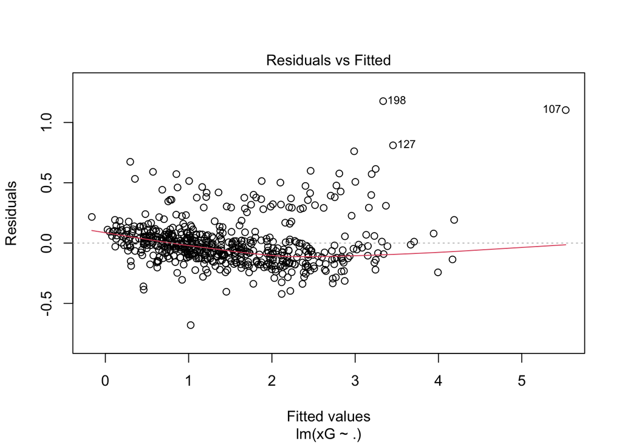

```r
plot(model1, 1)
```

The same is visualised below using the histogram plot

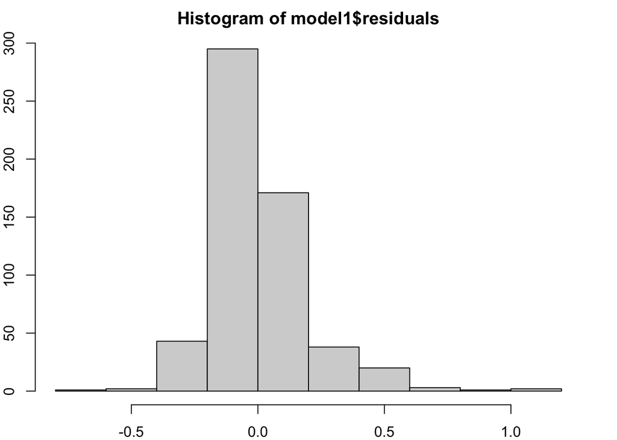

```r
par(mar=c(2,2,2,2))
hist(model1$residuals)
```

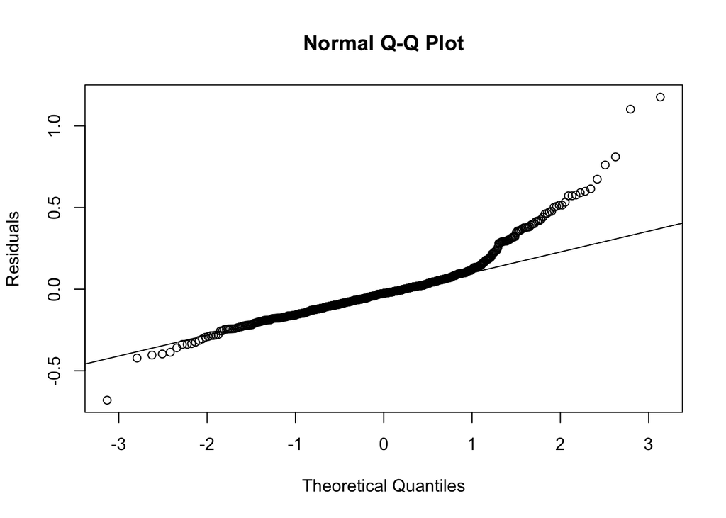

```r
qqnorm(model1$residuals,ylab = "Residuals")
qqline(model1$residuals)
```

#### Linear model using the significant attributes only

```r
sig_data = subset(data, select = c(xG, xGA, npxG, npxGA, deep, deep_allowed, scored, missed, xpts, result, HC.x))
str(sig_data)
```

```
## 'data.frame':    576 obs. of  11 variables:
##  $ xG          : num  2.235 0.842 3.184 1.2 1.341 ...
##  $ xGA         : num  0.842 2.235 1.2 3.184 1.599 ...
##  $ npxG        : num  2.235 0.842 2.423 1.2 1.341 ...
##  $ npxGA       : num  0.842 2.235 1.2 2.423 1.599 ...
##  $ deep        : int  11 5 9 1 4 5 0 5 5 6 ...
##  $ deep_allowed: int  5 11 1 9 6 7 9 5 5 4 ...
##  $ scored      : int  4 1 5 0 1 3 3 0 0 1 ...
##  $ missed      : int  1 4 0 5 1 0 0 0 0 1 ...
##  $ xpts        : num  2.386 0.441 2.631 0.252 1.017 ...
##  $ result      : num  1 -1 1 -1 0 1 1 0 0 0 ...
##  $ HC.x        : int  11 11 1 1 3 5 2 6 6 3 ...
```

Plots of the trend between the significant attributes and the label - xG

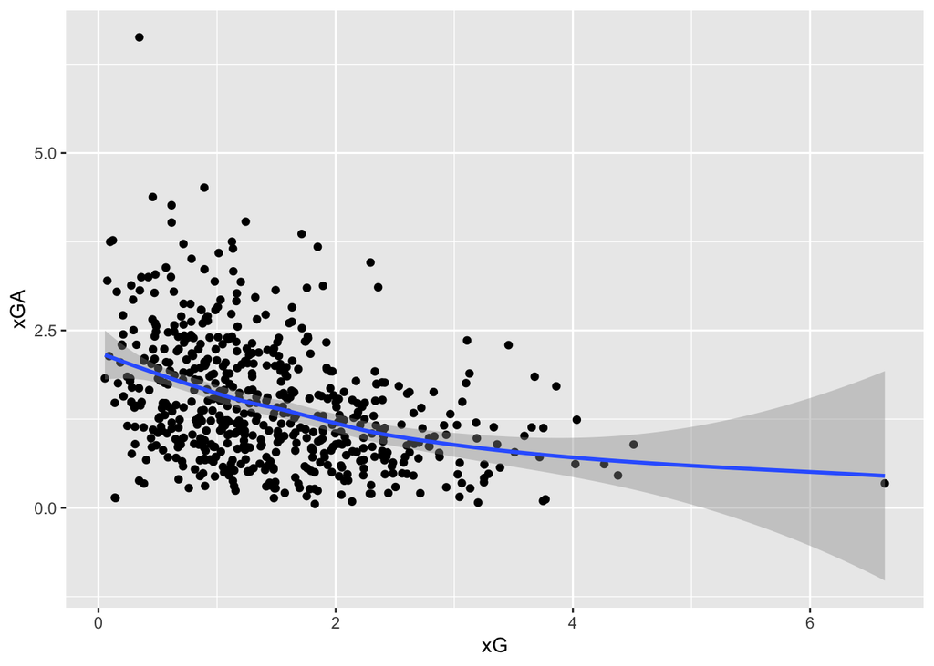

```r
ggplot(data,aes(x=xG,y=xGA))+geom_point()+geom_smooth()
```

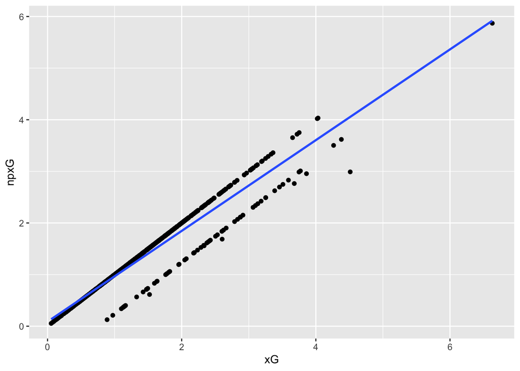

```r
ggplot(data,aes(x=xG,y=npxG))+geom_point()+geom_smooth(method='lm',se=FALSE)
```

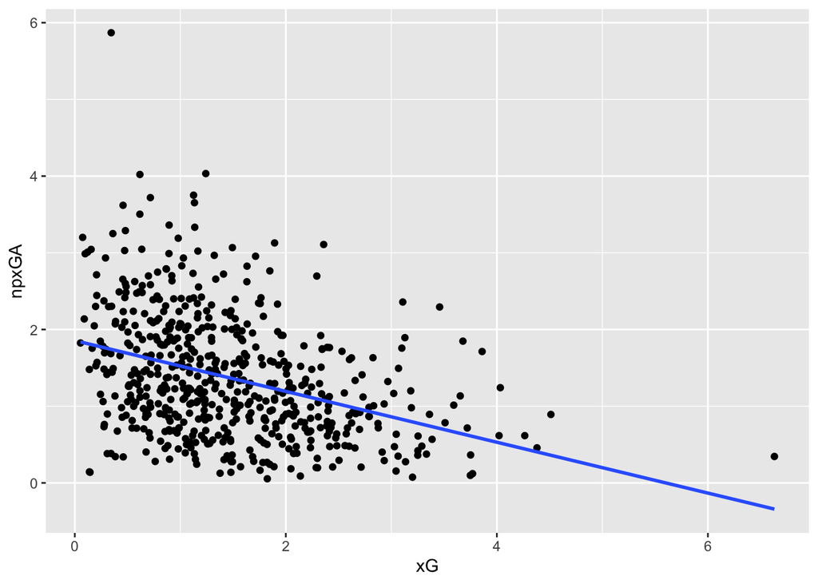

```r
ggplot(data,aes(x=xG,y=npxGA))+geom_point()+geom_smooth(method='lm',se=FALSE)
```

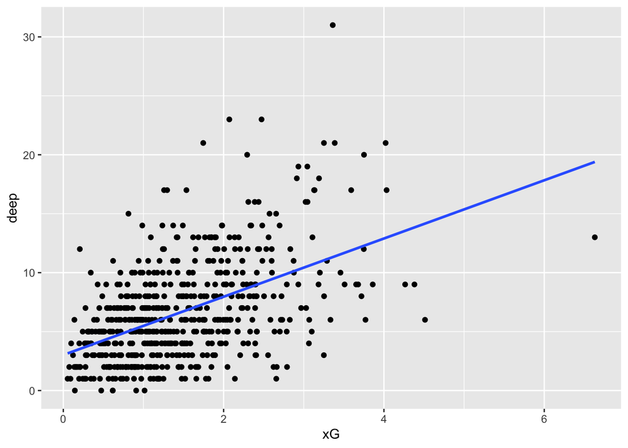

```r
ggplot(data,aes(x=xG,y=deep))+geom_point()+geom_smooth(method='lm',se=FALSE)
```

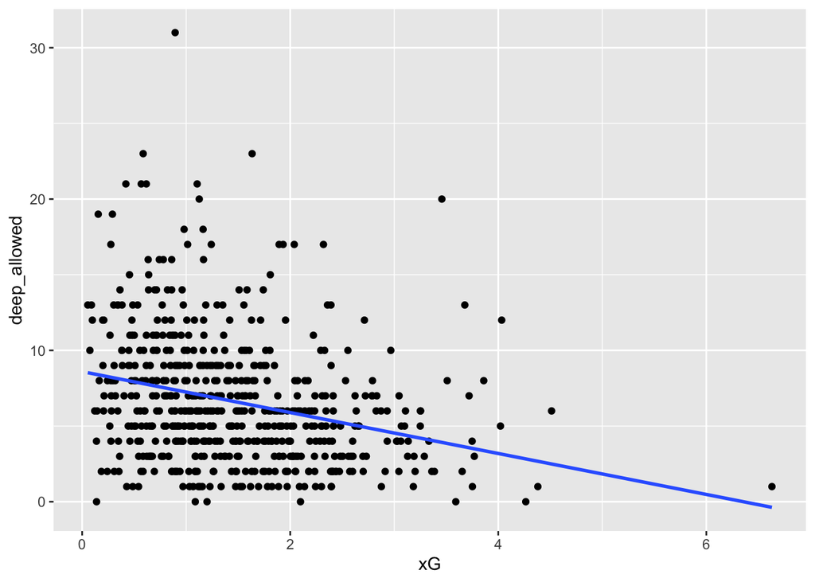

```r
ggplot(data,aes(x=xG,y=deep_allowed))+geom_point()+geom_smooth(method='lm',se=FALSE)
```

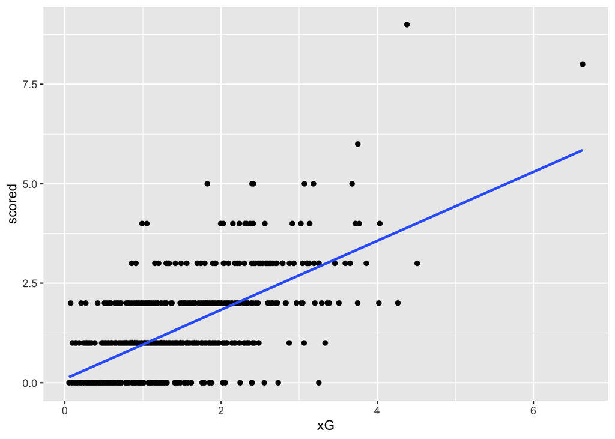

```r
ggplot(data,aes(x=xG,y=scored))+geom_point()+geom_smooth(method='lm',se=FALSE)
```

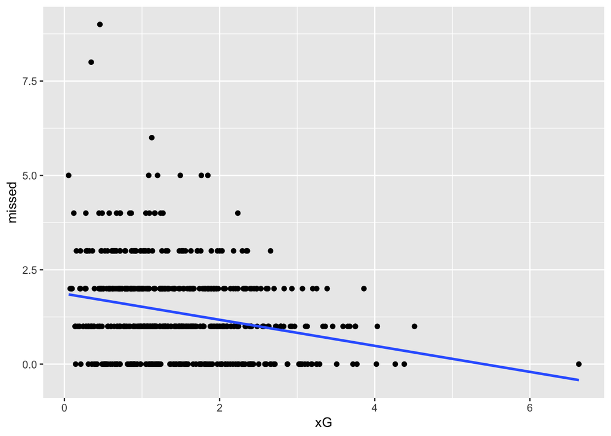

```r
ggplot(data,aes(x=xG,y=missed))+geom_point()+geom_smooth(method='lm',se=FALSE)
```

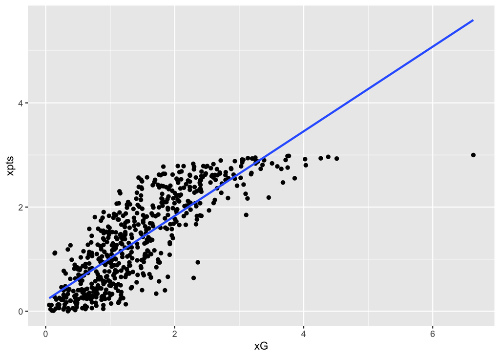

```r
ggplot(data,aes(x=xG,y=xpts))+geom_point()+geom_smooth(method='lm',se=FALSE)
```

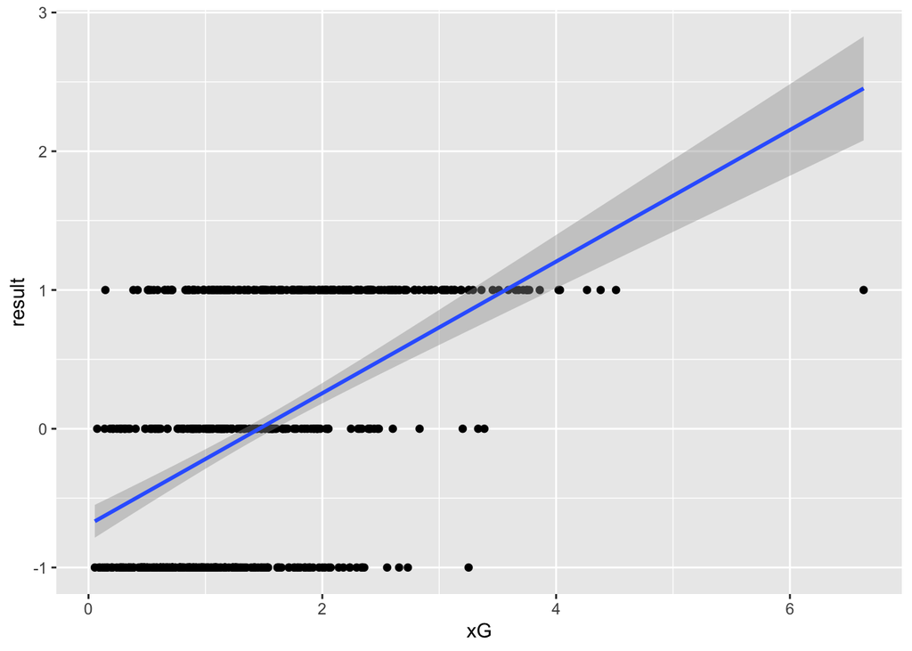

```r
ggplot(data,aes(x=xG,y=result))+geom_point()+geom_smooth(method='lm')
```

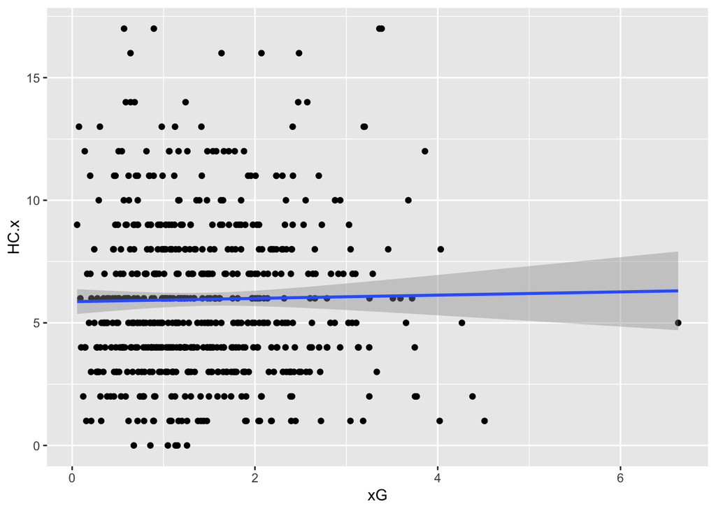

```r
ggplot(data,aes(x=xG,y=HC.x))+geom_point()+geom_smooth(method='lm')
```

Training the model 2

```r
set.seed(123)
train_samples <- sig_data$xG %>%
  createDataPartition(p=0.8,list=FALSE)
head(train_samples)
```

```
##      Resample1
## [1,]         1
## [2,]         2
## [3,]         3
## [4,]         8
## [5,]         9
## [6,]        10
```

```r
train <- sig_data[train_samples,]
test <- sig_data[-train_samples,]
model2 <- lm(xG~.,data=train)
```

The dataset is split into train and test set and the model is trained - model2

Summary

```r
summary(model2)
```

```
##
## Call:
## lm(formula = xG ~ ., data = train)
##
## Residuals:
##      Min       1Q   Median       3Q      Max
## -0.56174 -0.10837 -0.03337  0.04486  1.28984
##
## Coefficients:
##               Estimate Std. Error t value Pr(>|t|)
## (Intercept)  -0.508588   0.060772  -8.369 7.30e-16 ***
## xGA           0.164450   0.044437   3.701 0.000241 ***
## npxG          0.713885   0.027110  26.333  < 2e-16 ***
## npxGA         0.042737   0.042866   0.997 0.319303
## deep          0.002120   0.002634   0.805 0.421299
## deep_allowed  0.002260   0.002703   0.836 0.403556
## scored        0.098852   0.012724   7.769 5.34e-14 ***
## missed       -0.036339   0.012687  -2.864 0.004375 **
## xpts          0.416334   0.036117  11.527  < 2e-16 ***
## result       -0.093887   0.020567  -4.565 6.44e-06 ***
## HC.x         -0.001422   0.002938  -0.484 0.628673
## ---
## Signif. codes:  0 '***' 0.001 '**' 0.01 '*' 0.05 '.' 0.1 ' ' 1
##
## Residual standard error: 0.2011 on 453 degrees of freedom
## Multiple R-squared:  0.9493, Adjusted R-squared:  0.9482
## F-statistic: 847.8 on 10 and 453 DF,  p-value: < 2.2e-16
```

INFERENCE: The r squared and the adjusted r squared value are 0.9493 and 0.9482 respectively.

```r
sigma(model2)
```

```
## [1] 0.2011251
```

```r
confint(model2)
```

```
##                     2.5 %       97.5 %
## (Intercept)  -0.628018606 -0.389156615
## xGA           0.077122293  0.251777533
## npxG          0.660607978  0.767162655
## npxGA        -0.041504008  0.126977797
## deep         -0.003055915  0.007295646
## deep_allowed -0.003052106  0.007571951
## scored        0.073846541  0.123857150
## missed       -0.061272539 -0.011405302
## xpts          0.345356845  0.487311895
## result       -0.134304570 -0.053469381
## HC.x         -0.007194537  0.004351402
```

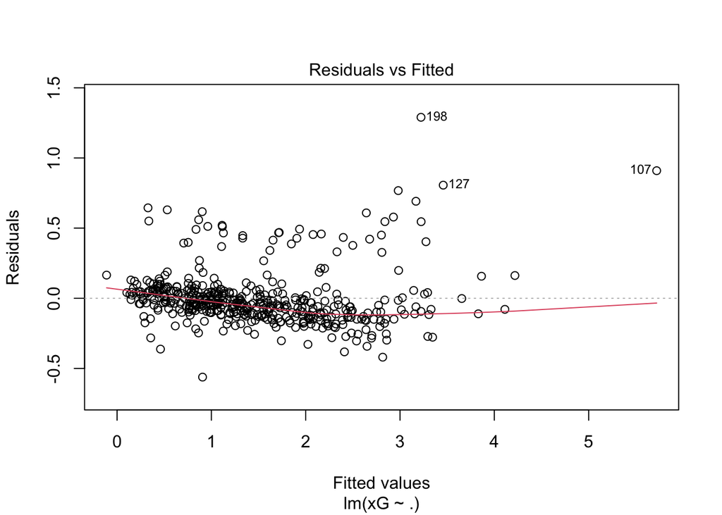

```r
plot(model2, 1)
```

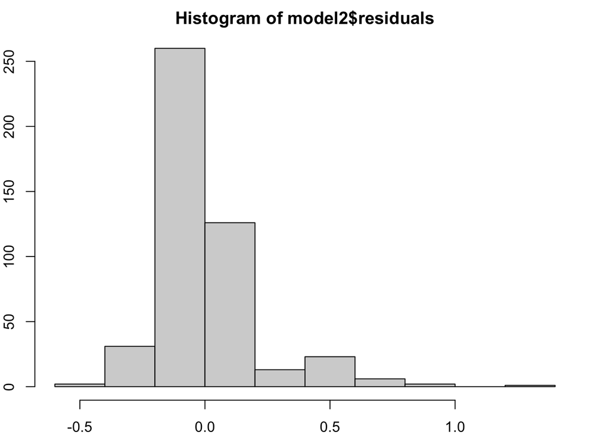

```r
par(mar=c(2,2,2,2))
hist(model2$residuals)
```

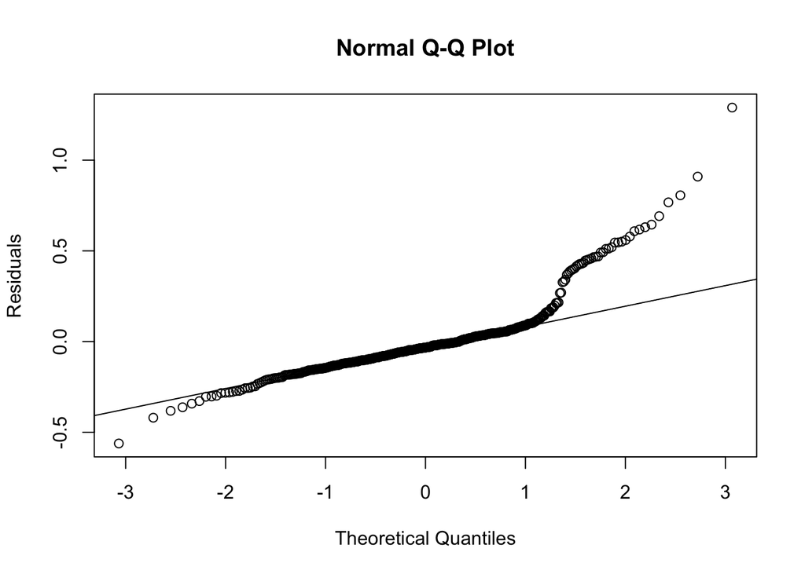

```r
qqnorm(model2$residuals,ylab = "Residuals")
qqline(model2$residuals)
```

The same is justified in the above diagram where most of the points (normalised) lie on the line

Now, we can check the model on the test dataset:

```r
pred <- model2 %>%
  predict(test)
R2 <- R2(pred,test$xG)
R2
```

```
## [1] 0.9354071
```

0.935 is a very good score for the test data set in terms of R squared. (Closer it is to 1, the better the model is)

```r
RMSE <- RMSE(pred,test$xG)
RMSE
```

```
## [1] 0.2134443
```

A low value of RMSE also supports the claim that model 2 is good!

CONCLUSON: The data acquired was explored and analysed from numerical and diagramatic perspectives. Then the visualisation tools were used to understand the data and in turn generate a linear regression model using statistically significant attributes that performed really well (R squared = 0.95).